# Technology and Social Change

Lecture 15: Artificial Intelligence and the Political Economy of Technological Change

Bogdan G. Popescu

bgpopescu@tec.mx

Tecnológico de Monterrey

# Part 1: The Puzzle

## AI and the Political Economy of Technological Change

Will AI create shared prosperity—or concentrated gains?

From steam engines to large language models: **the same political-economy questions**

The same AI can lift wages or replace workers — depending on **institutions and choices about deployment**

Same fundamental questions as the Industrial Revolution

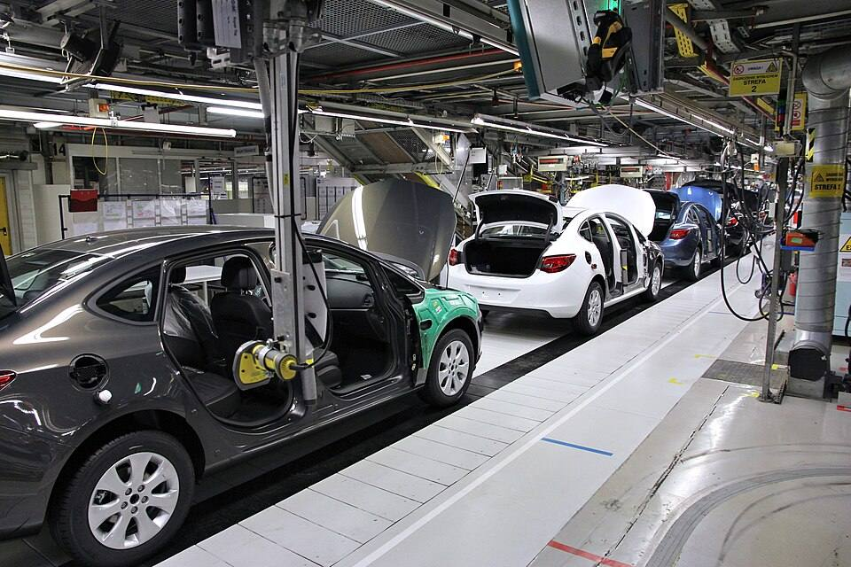

A modern car assembly line: automation has reshaped manufacturing for decades. AI now extends this transformation to cognitive work. Source: Marek Slusarczyk / Wikimedia Commons (CC BY 3.0).

## The Productivity-Pay Gap

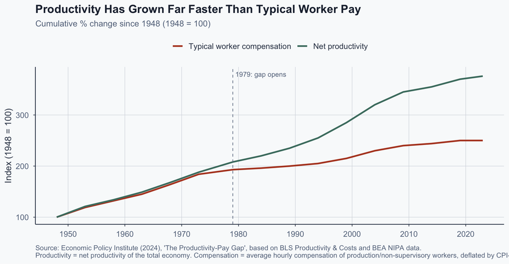

Figure 1

## Why This Matters

**The chart is not just a number** — it is the lived experience of a generation of workers.

- Cashiers replaced by self-checkout
- Paralegals worried about generative AI
- Manufacturing workers displaced by robots

**Now AI raises the same question on a much larger scale.** Will it lift wages, or widen the gap further?

## Three Guiding Questions

**1. Why did productivity rise while wages stagnated after 1980?**

**2. Will AI raise worker productivity — or replace workers?**

**3. Will AI’s gains be broadly shared — or concentrated among a few firms and workers?**

## Learning Objectives

By the end of this lecture, you should be able to:

1. **Explain the productivity bandwagon** and the two conditions it requires
2. **Use historical evidence** (the Engels Pause) to understand AI’s potential trajectory
3. **Evaluate empirical evidence** on whether AI complements or replaces workers
4. **Identify policy levers** that can redirect AI toward shared prosperity

# Part 2: The Framework — Then and Now

## The Productivity Bandwagon

**The popular belief**:

*Technology raises productivity → firms expand → labor demand rises → wages follow.*

Wages “ride along” on the productivity bandwagon.

**But Acemoglu & Johnson (2023) ask**: Is this automatic? Or does it depend on conditions that can fail?

*Two conditions must hold for the bandwagon to work.*

## Condition 1: Does Technology Need Workers?

**Marginal productivity**: does the new technology *raise* the value of an additional worker, or *replace* workers altogether?

**Complement** → workers more valuable

- Spreadsheets made accountants more productive — demand for accountants *grew*

**Substitute** → workers less valuable

- Self-checkout kiosks replaced cashiers — demand for cashiers *fell*

**Question for AI**

Which tasks does it complement, and which does it substitute?

## Condition 2: Do Workers Have Bargaining Power?

**Even when technology needs workers**, gains may not reach them. Workers need *power* to capture them.

**Strong bargaining power** → workers share gains

- Postwar US (1948–1979): unions, tight labor markets, rising minimum wage — productivity and wages rose together

**Weak bargaining power** → owners keep gains

- Post-1980: union decline, globalization, weakened labor standards — productivity rose, wages didn’t

**Question for AI**

Who controls AI deployment — workers or just firms?

## When the Bandwagon Breaks

**The bandwagon needs BOTH conditions.** If either fails, productivity rises but wages stagnate.

- Condition 1 fails → technology *substitutes* for labor
- Condition 2 fails → workers lack the power to capture gains
- **Both can fail at once** → maximum inequality

*The post-1980 chart you just saw shows exactly this pattern.*

## The Engels Pause: 1790–1840

**During early industrialization** (Britain, 1790–1840):

- Productivity rose substantially as factories spread
- But **real wages stagnated for 50+ years**
- Living conditions worsened: child labor, urban slums, long hours

*Friedrich Engels documented this gap. Economic historians now call it “the Engels Pause.”*

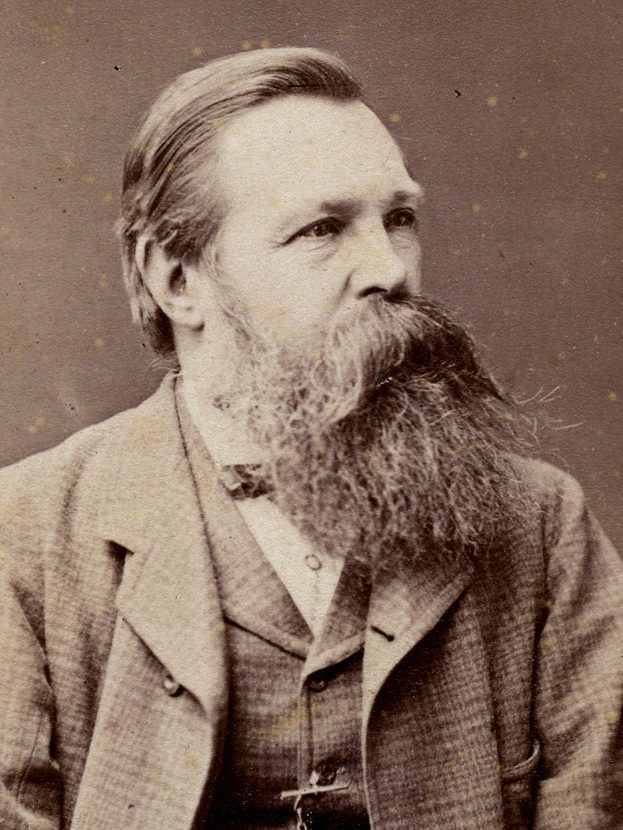

Friedrich Engels (1820–1895): his observations on workers’ conditions during industrialization gave the “Engels Pause” its name. Source: Wikimedia Commons (public domain).

## Why the Bandwagon Broke Then

Both conditions failed simultaneously:

**Condition 1 failed**: early factory machinery *substituted* for skilled artisans (handloom weavers replaced by power looms)

**Condition 2 failed**: workers had almost no bargaining power

- Unions were illegal (Combination Acts, 1799–1824)
- Surplus rural labor flooded cities — workers were easy to replace
- No vote, no welfare state, no factory inspections

**Result**: productivity gains went to industrialists, not workers — for half a century.

## Why the Bandwagon Eventually Worked

After 1840, both conditions were gradually restored — through **deliberate institutional change**:

- **Trade unions legalized** (1824, 1871) — restored Condition 2
- **Mass public schooling** (Forster Act 1870) — raised worker skills, restored Condition 1
- **Suffrage extended** (1867, 1884) — gave workers political voice

**By 1900, productivity gains were broadly shared.**

*The lesson: the bandwagon does not run automatically. Institutions decide whether it carries everyone.*

# Part 3: AI Today — What Does the Evidence Show?

## What Does AI Do to Tasks?

Recall from Lecture 11: **jobs = bundles of tasks**; technology affects *tasks*, not whole jobs.

**AI is different from earlier automation in important ways**:

| Dimension | Past Automation | AI |
| --- | --- | --- |
| **Tasks affected** | Routine manual | Cognitive + creative |
| **Workers displaced** | Factory, farm | Professionals, analysts |
| **Initial effect** | Skill destruction | Skill compression |
| **Speed** | Decades | Months to years |

*The Engels Pause took 50 years. AI may compress that timeline — because cloud deployment is near-instant, AI affects cognitive tasks across many sectors at once, and adoption requires no new factories.*

## Two Big Questions about AI

We have a framework. Now we ask the same two questions of AI:

**Question 1 (Condition 1)**: Does AI complement workers — or substitute for them?

**Question 2 (Condition 2)**: Are workers gaining bargaining power — or losing it?

*The empirical evidence so far gives us partial, sometimes contradictory, answers.*

## Study 1: Brynjolfsson, Li & Raymond (2023)

**Setting**: One Fortune 500 company

- 5,172 customer-service workers
- About 3 million customer chats
- AI tool: GPT-based chat assistant suggesting real-time responses

**Design**: AI **assists** workers, does not replace them

**Outcome**: Resolutions per hour (problems solved per hour)

## Study 1: Results—Biggest Gains for Novice Workers

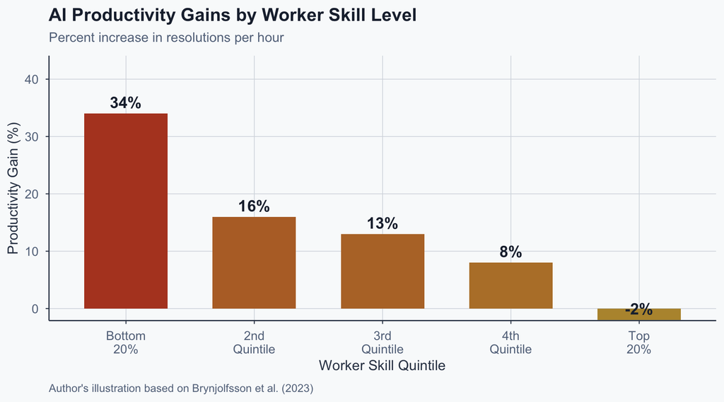

Figure 2: AI productivity gains are largest for lower-skill workers

## Study 2: Noy & Zhang (2023)

**Setting**: Randomized experiment (online)

- 453 college-educated professionals
- Tasks: realistic writing (emails, reports, marketing)
- AI tool: ChatGPT

**Design**: Treatment group uses AI; control group does not

**Outcomes**: Time to complete + quality of output (graded by humans)

## Study 2: AI Compresses the Performance Gap

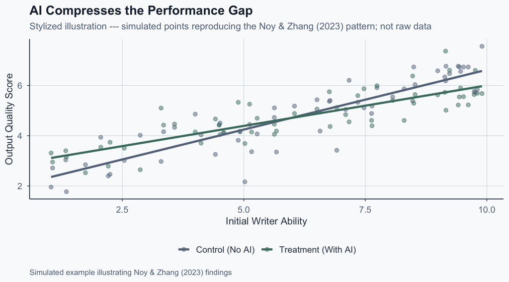

Figure 3: AI flattens the quality gap between strong and weak writers

## Interpreting the Productivity Evidence

**What do these studies tell us?**

- AI **can** raise worker productivity (Condition 1 may hold)
- Current AI often **complements** rather than substitutes
- Gains are largest for **lower-skill** workers (skill compression)

**But**:

- These studies test AI as **tool** (worker + AI), not **replacement**
- Distribution question remains: Do workers capture gains? (Condition 2)

## Study 3: Robots and Jobs (Acemoglu & Restrepo, 2020)

**U.S. local labor markets and industrial robots**

- +1 robot per 1,000 workers leads to:
  - Employment rate falls 0.20 pp
  - Average wages fall 0.42%
- Effects strongest in manufacturing regions

**Implication**: Displacement was NOT offset by task creation locally

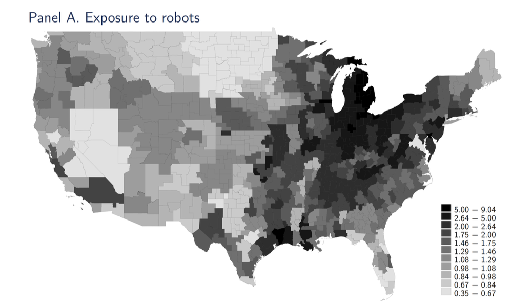

Source: Acemoglu & Restrepo (2020, Fig. 6)

## Video: Acemoglu on AI and Inequality

[video not shown]

Source: [Acemoglu on AI and Inequality](https://www.youtube.com/watch?v=FLzgjCAXoks)

1. What historical example shows technology can increase inequality?
2. What two main ways is AI likely to be used against workers?
3. Why can we not rely on “the market” alone for AI outcomes?
4. How is AI linked to threats to democracy?

## The Evidence in Summary

How does each study map onto the two conditions?

| Study | Complement or Substitute? | Tests Condition | Bottom Line |
| --- | --- | --- | --- |
| **Brynjolfsson, Li & Raymond (2023)** | Complement | C1: marginal productivity | AI raises productivity, especially for novices |
| **Noy & Zhang (2023)** | Complement | C1: marginal productivity | AI compresses skill gaps in writing |
| **Acemoglu & Restrepo (2020)** | Substitute | C1: marginal productivity | Robots reduced employment and wages locally |

*All three speak to **Condition 1**. None directly tests **Condition 2** — whether workers actually capture the gains.*

## AI Exposure: Who Is Affected?

**Eloundou, Manning, Mishkin & Rock (2024)**:

- ~80% of U.S. workers have **at least 10%** of tasks exposed to LLMs
- ~19% have **at least 50%** of tasks exposed
- Unlike robots, AI hits **high-skill cognitive** workers hardest

This inverts the usual automation pattern

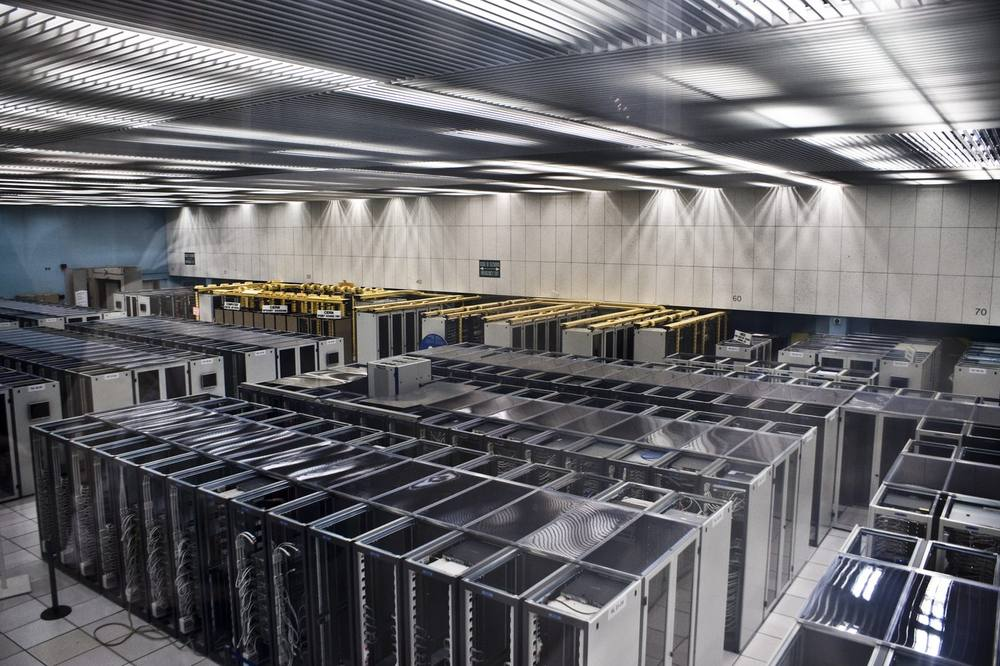

A modern data center: the physical infrastructure powering AI. The concentration of computing resources in a few firms raises questions about who controls AI’s economic gains. Source: CERN / Wikimedia Commons.

## AI Exposure by Occupation Group

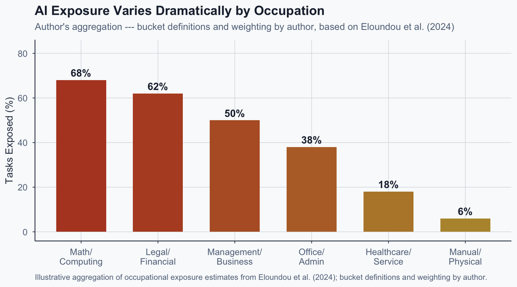

Figure 4: AI exposure is highest for cognitive occupations

## Capability vs. Reality: The AI Adoption Gap

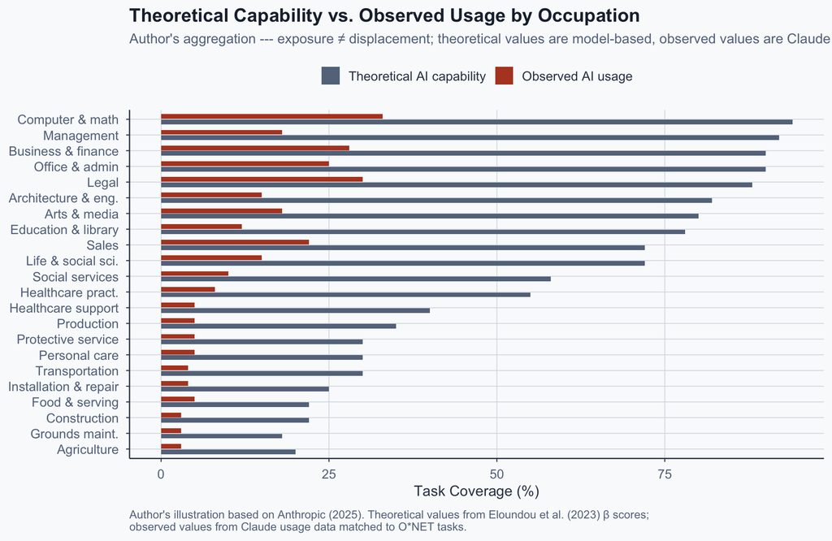

Figure 5: Theoretical AI capability far exceeds actual observed usage across all occupational categories

## Early Warning: Young Worker Hiring Slowdown

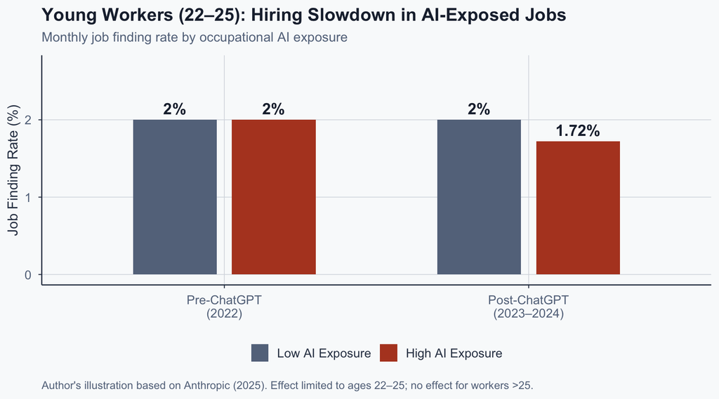

Figure 6: Job finding rates for young workers in AI-exposed occupations show early decline

**Caveat**: This is *early warning evidence*, not definitive proof of AI displacement. The pattern is correlational — post-ChatGPT, in exposed occupations, for one age group — and consistent with multiple causes.

## Macro Projections: Massive Disagreement

| Source | GDP Impact | Method | Horizon |
| --- | --- | --- | --- |
| **Acemoglu (2025)** | **+1.0%** | General equilibrium model; task-level substitution | ~10 years |
| **McKinsey (2023)** | **+6.0%** | Productivity potential across use cases | ~decade |
| **Goldman Sachs (2023)** | **+7.0%** | Macro projection (level effect on output) | ~10 years |

These estimates differ by **an order of magnitude** because of fundamentally different modeling choices, not disagreement about AI’s capabilities.

**Takeaway**: Be skeptical of any single headline number. The range itself is the information.

## Who Is Actually Exposed? The Measurement Problem

**Boix et al. (2026)**: Three popular AI exposure indexes yield **contradictory** sector rankings

| Sector | Felten | Brynjolfsson | Webb |
| --- | --- | --- | --- |
| Finance & Insurance | 1 | 1 | 7 |
| Agriculture | 13 | 13 | **1** |
| Manufacturing | 9 | 8 | **2** |

Cells show each sector’s **rank** on each index (1 = most exposed to AI). The three measures use different methods — task-capability matching (Felten), suitability for machine learning (Brynjolfsson), patent-task overlap (Webb) — and disagree sharply on who is most affected.

If we cannot agree on *who* is exposed, forecasts about AI’s winners and losers remain deeply uncertain

## New Task Creation: Grounds for Cautious Optimism

**Autor, Chin, Salomons & Seegmiller (2024)**:

- ~60% of employment in 2018 is in job titles that **barely existed** in 1940
- New work creation has historically been the **primary** engine of employment growth
- But the pace of new work has **slowed since 1980**, especially for less-educated workers

**Hope for AI**: If AI creates valuable new tasks, reinstatement can offset displacement—but this requires deliberate institutional effort

# Part 4: The Choice

## Institutional Responses: What Might Work?

| Policy | Condition Targeted |
| --- | --- |
| **Education/retraining** | Condition 1: maintain marginal productivity |
| **Collective bargaining** | Condition 2: restore rent sharing |
| **Income support (UBI)** | Cushion displacement transitions |
| **Antitrust/competition** | Reduce market power concentration |
| **AI governance** | Shape technology development direction |

**No single policy suffices**—combinations are needed, as during industrialization

Source: Author’s illustration based on Acemoglu & Johnson (2023)

[figure not shown]

Garment workers’ strike march, New York, 1958. Collective bargaining has historically been a key mechanism for workers to share in productivity gains. Source: Kheel Center, Cornell University / Wikimedia Commons (CC BY 2.0).

## AI Concentration: Economic and Political

**The economic risk** — “winner-take-most”:

- Foundation models cost billions to build — only a handful of firms can compete
- Increasing returns to scale: more data → better models → more users → more data
- **Monopsony risk** in AI-adjacent labor markets: few employers, many displaced workers — *Condition 2 weakens*

**The political risk** — regulatory capture (Boix et al., 2026):

- Big Tech capex surged from **$36B (2015) to $400B (2025)** — over a third of all US private IT investment
- Data centers and chips are **immobile** assets — AI firms now have strong incentives to lobby and shape regulation

*Concentration is not just an economic problem — it shapes who decides what AI becomes.*

## Redirecting AI: From Displacement to Augmentation

**Acemoglu & Johnson (2023)**: The *direction* of AI is a choice, not a given

- Current incentives favor **automation** (tax-advantaged capital, cheap compute)
- Alternative: **human-complementary AI** that creates new tasks
- Policy levers: equalize capital/labor taxation, fund augmentation R&D, give workers voice in deployment

**Will we create shared prosperity, or repeat the Engels Pause?**

## Summary: Key Takeaways

1. The **productivity bandwagon is not automatic** — it requires marginal productivity AND bargaining power
2. **History warns**: productivity can rise while wages stagnate for generations (the Engels Pause)
3. **Current AI evidence is mixed**: AI often complements workers, but also displaces them, with uneven exposure
4. **Concentration is political**: who controls AI shapes who captures the gains
5. **The direction of AI is a choice** — institutions and policy can redirect it from displacement to augmentation

## References (1/2)

- Acemoglu, D. (2025). The simple macroeconomics of AI. *Econ. Policy*, 40(121), 13–58.
- Acemoglu, D., & Johnson, S. (2023). *Power and Progress*. PublicAffairs.
- Acemoglu, D., & Restrepo, P. (2019). Automation and new tasks. *J. Econ. Perspect.*, 33(2), 3–30.
- Acemoglu, D., & Restrepo, P. (2020). Robots and jobs. *J. Polit. Econ.*, 128(6), 2188–2244.
- Acemoglu, D., & Restrepo, P. (2022). Tasks, automation, and the rise in U.S. wage inequality. *Econometrica*, 90(5), 1973–2016.
- Anthropic. (2025). [The labor market impacts of AI: Evidence from real-world usage](https://www.anthropic.com/research/labor-market-impacts). Anthropic Research.
- Autor, D. H. (2015). Why are there still so many jobs? *J. Econ. Perspect.*, 29(3), 3–30.
- Autor, D., Chin, C., Salomons, A., & Seegmiller, B. (2024). New frontiers. *Q. J. Econ.*, 139(3), 1399–1465.

## References (2/2)

- Boix, C., Becher, M., González-Rostani, V., & Stegmueller, D. (2026). AI’s economy and its political and institutional consequences. APSA Task Force on AI and Political Science.
- Boix, C. (2022). AI and the economic and informational foundations of democracy. In J. B. Bullock et al. (Eds.), *The Oxford Handbook of AI Governance*. Oxford UP.
- Brynjolfsson, E., Li, D., & Raymond, L. R. (2023). *Generative AI at Work* (NBER WP 31161).
- Brynjolfsson, E., Rock, D., & Syverson, C. (2021). The productivity J-curve. *AEJ: Macro.*, 13(1), 333–372.
- Dell’Acqua, F., et al. (2023). *Navigating the Jagged Technological Frontier* (HBS WP 24-013).
- Eloundou, T., Manning, S., Mishkin, P., & Rock, D. (2024). GPTs are GPTs: Labor market impact potential of LLMs. *Science*, 384(6702), 1306–1308.
- Goldin, C., & Katz, L. F. (2008). *The Race between Education and Technology*. Harvard UP.
- Noy, S., & Zhang, W. (2023). Experimental evidence on the productivity effects of generative artificial intelligence. *Science*, 381(6654), 187–192.
- Peng, S., Kalliamvakou, E., Cihon, P., & Demirer, M. (2023). The impact of AI on developer productivity: Evidence from GitHub Copilot. *arXiv:2302.06590*.

# Appendix

## Appendix: Automation and Inequality (Acemoglu & Restrepo, 2022)

**U.S. economy, 1980–2016**:

- 50–70% of U.S. wage structure changes explained by automation
- Wage declines largest in routine-task occupations
- Concentrated in **middle-skill** occupations (job polarization)
- Disproportionately affects **non-college** workers

**Historical parallel**: Artisan displacement during the Industrial Revolution

## Appendix: AI and Coding Productivity (Peng et al., 2023)

**Peng, Kalliamvakou, Cihon & Demirer (2023)**: GitHub Copilot RCT

- Developers completed coding tasks **55.8% faster** with AI
- Randomized controlled trial with professional developers

**Implications**:

- Large productivity gains in well-defined coding tasks
- Consistent with Brynjolfsson and Noy & Zhang findings
- Human judgment remains critical for code review and design

## Appendix: Macro Projections Bar Chart

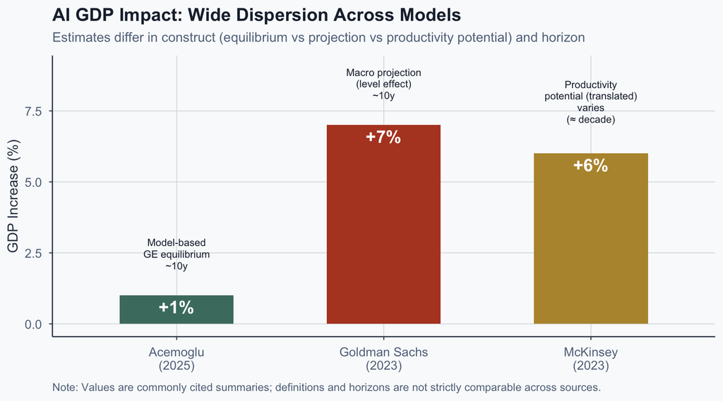

Figure 7: Estimates of AI’s macroeconomic impact vary by an order of magnitude